# Paso 3: Modelo A (baseline) y backtesting

**El modelo A formaliza tus premisas de negocio:**

> presupuesto diario = **base reciente** (nivel por producto-tienda) × **factor estacional mensual** (forma de 2025, por familia) × **participación del día** (curva por día de semana por tienda + días especiales)

**¿Por qué medirlo con backtesting?** Porque un pronóstico no se evalúa por lo razonable que suena sino por el error que comete. El protocolo: nos paramos a **fin de abril 2026**, generamos el presupuesto de mayo-junio usando solo información disponible hasta esa fecha, y lo comparamos contra la venta real de mayo-junio (que conocemos pero el modelo no vio). En paralelo evaluamos el **método anterior** (promedio repartido lineal) sobre el mismo período: la diferencia entre ambos es la mejora medible y defendible ante negocio.

**Métrica: WMAPE** (Weighted Mean Absolute Percentage Error) = Σ|error| / Σ(real). Es el estándar en retail porque pondera cada producto por su volumen: equivocarse 50% en un producto que vende 3 unidades importa menos que equivocarse 10% en la medialuna. La reportamos a tres niveles de agregación, porque cada uno responde una pregunta distinta:

- **sku-día:** ¿acierto la venta de cada producto cada día? (la vara más exigente)
- **tienda-día:** ¿acierto el volumen diario de la tienda? (clave para dotación y producción)
- **sku-mes:** ¿acierto el total mensual por producto? (clave para compras/abastecimiento)

```python
import pandas as pd
import numpy as np
import matplotlib.pyplot as plt

daily = pd.read_parquet('daily.parquet')
maestro = pd.read_parquet('maestro.parquet')

# --- configuración del backtest ---
BASE_MESES   = [3, 4]   # lo que el modelo usa como "últimos 2 meses"
TARGET_MESES = [5, 6]   # lo que debe predecir
hist = daily[daily['FECHA'] <= '2026-04-30']    # única información disponible
real = daily[(daily['año'] == 2026) & (daily['FECHA'].dt.month.isin(TARGET_MESES))]
```

## 1. Componente "nivel": base por producto-tienda

Promedio mensual de los dos últimos meses conocidos (mar-abr en el backtest; may-jun en el presupuesto final). Define **cuánto** vende cada producto hoy.

```python
base = (hist[(hist['año'] == 2026) & (hist['FECHA'].dt.month.isin(BASE_MESES))]
        .groupby(['Tienda', 'CÓDIGO'])['CANTIDAD'].sum()
        .div(len(BASE_MESES))
        .rename('base_mensual').reset_index()
        .merge(maestro[['CÓDIGO', 'FAMILIA']], on='CÓDIGO', how='left'))
print(f"{len(base)} combinaciones producto-tienda activas en la base")
```

```
352 combinaciones producto-tienda activas en la base
```

## 2. Componente "forma mensual": factor estacional por familia

Para cada familia: unidades del mes m de 2025 ÷ promedio de la misma ventana base en 2025. **¿Por qué por familia y no por producto?** Dos razones: (a) el 16% del volumen 2026 son productos que no existían en 2025 — no tienen historia propia, pero heredan la estacionalidad de su familia; (b) a nivel producto la señal anual es ruidosa; la familia agrega y estabiliza.

Salvaguardas (importantes en producción):

- familias con menos de 500 unidades/año caen al factor total de la compañía (fallback),
- el factor se recorta al rango [0.4, 2.5] para que una familia errática no genere disparates.

```python
h25 = hist[hist['año'] == 2025]
fam_mes = h25.groupby(['FAMILIA', h25['FECHA'].dt.month])['CANTIDAD'].sum().unstack(fill_value=0)
fam_base = fam_mes[BASE_MESES].mean(axis=1)
factor_fam = fam_mes.div(fam_base, axis=0)

tot_mes = h25.groupby(h25['FECHA'].dt.month)['CANTIDAD'].sum()
factor_tot = tot_mes / tot_mes[BASE_MESES].mean()

chicas = fam_mes.sum(axis=1) < 500
factor_fam.loc[chicas] = factor_tot.values
factor_fam = factor_fam.clip(0.4, 2.5)
print(f"Familias con factor propio: {(~chicas).sum()} | con fallback al total: {chicas.sum()}")
```

```
Familias con factor propio: 19 | con fallback al total: 10
```

## 3. Componente "forma semanal": pesos por día de semana y tienda

Promedio de venta de cada día de semana (ene-abr 2026, sin lunes ni feriados), normalizado para que mar-dom sume 1. Usamos el promedio por día —no la suma— para que meses con distinta cantidad de martes no distorsionen.

```python
d26 = hist[(hist['año'] == 2026)
           & (hist['FECHA'] != '2026-04-02')     # feriado de Malvinas: día atípico, fuera
           & (hist['dow'] > 0)]
por_dia = d26.groupby(['Tienda', 'FECHA', 'dow'])['CANTIDAD'].sum().reset_index()
w = por_dia.groupby(['Tienda', 'dow'])['CANTIDAD'].mean()
w = w / w.groupby('Tienda').transform('sum')
w.unstack('Tienda').round(3)
```

| Tienda dow | Sinclair | Ugarteche |
| --- | --- | --- |
| 1 | 0.149 | 0.144 |
| 2 | 0.136 | 0.134 |
| 3 | 0.130 | 0.138 |
| 4 | 0.156 | 0.167 |
| 5 | 0.201 | 0.216 |
| 6 | 0.227 | 0.201 |

## 4. Calendario con días especiales

Cada día del período recibe un multiplicador: 1 para día normal, 0 si está cerrado (todos los lunes + Navidad), y un factor especial para feriados abiertos. El multiplicador del feriado abierto (×1.93) sale del promedio de los dos casos observables sin mirar el futuro del backtest: 9/7/2025 (2.00) y 1/5/2025 (1.86).

```python
FERIADO_ABIERTO = 1.93

def calendario(año, meses, feriados_abiertos={}, cerrados=set()):
    fechas = pd.date_range(f'{año}-{min(meses):02d}-01',
                           pd.Timestamp(f'{año}-{max(meses):02d}-01') + pd.offsets.MonthEnd(0))
    cal = pd.DataFrame({'FECHA': fechas})
    cal['dow'] = cal['FECHA'].dt.dayofweek
    cal['mult'] = 1.0
    cal.loc[cal['dow'] == 0, 'mult'] = 0.0                 # lunes: cerrado (incluye feriados)
    for f, m in feriados_abiertos.items():
        cal.loc[cal['FECHA'] == pd.Timestamp(f), 'mult'] = m
    for f in cerrados:
        cal.loc[cal['FECHA'] == pd.Timestamp(f), 'mult'] = 0.0
    return cal

# Backtest: 1/5 viernes feriado abierto; 22/6 se fuerza cerrado (premisa nueva: lunes no abren)
cal_bt = calendario(2026, TARGET_MESES,
                    feriados_abiertos={'2026-05-01': FERIADO_ABIERTO},
                    cerrados={'2026-06-22'})
```

## 5. El motor de pronóstico

La lógica: el total mensual del producto (base × factor estacional) se reparte entre los días según `peso(dow) × multiplicador`, normalizado para que el mes cierre exacto. Los flags `con_curva` y `con_estacionalidad` permiten apagar cada componente — así medimos cuánto aporta cada uno (*ablación*), y con ambos apagados reproducimos el método anterior (lineal).

```python
def pronosticar(base, cal, con_curva=True, con_estacionalidad=True):
    cal = cal.copy(); cal['mes'] = cal['FECHA'].dt.month
    filas = []
    for tienda in base['Tienda'].unique():
        c = cal.copy()
        if con_curva:
            c['peso'] = c['dow'].map(w.loc[tienda]).fillna(0) * c['mult']
        else:
            c['peso'] = (c['mult'] > 0).astype(float)      # reparto lineal entre días abiertos
        c['share'] = c.groupby('mes')['peso'].transform(lambda s: s / s.sum())
        bt = base[base['Tienda'] == tienda]
        for mes in sorted(c['mes'].unique()):
            f = (bt['FAMILIA'].map(factor_fam[mes]).fillna(factor_tot[mes]).values
                 if con_estacionalidad else 1.0)
            total_mes = bt['base_mensual'].values * f
            dias = c[c['mes'] == mes]
            matriz = np.outer(total_mes, dias['share'].values)      # productos × días
            df = pd.DataFrame(matriz, columns=dias['FECHA'])
            df['Tienda'] = tienda; df['CÓDIGO'] = bt['CÓDIGO'].values
            filas.append(df.melt(id_vars=['Tienda', 'CÓDIGO'], var_name='FECHA', value_name='pred'))
    out = pd.concat(filas); out['FECHA'] = pd.to_datetime(out['FECHA'])
    return out

pred_a   = pronosticar(base, cal_bt)                                          # Modelo A completo
pred_lin = pronosticar(base, cal_bt, con_curva=False, con_estacionalidad=False)  # método anterior
```

## 6. Evaluación

Cruzamos predicción y realidad con `outer` join: días donde el modelo predijo y no se vendió cuentan como error, y viceversa. El 22/6 se excluye del score: la tienda vendió pero la nueva premisa la considera cerrada — no es un error del modelo sino un cambio de regla.

```python
real_d = (real.groupby(['Tienda', 'CÓDIGO', 'FECHA'])['CANTIDAD'].sum()
              .rename('real').reset_index())

def evaluar(pred, nombre):
    ev = pred.merge(real_d, on=['Tienda', 'CÓDIGO', 'FECHA'], how='outer').fillna(0)
    ev = ev[ev['FECHA'] != pd.Timestamp('2026-06-22')]
    wm_sd = (ev['pred'] - ev['real']).abs().sum() / ev['real'].sum()
    dia = ev.groupby(['Tienda', 'FECHA'])[['pred', 'real']].sum()
    wm_d = (dia['pred'] - dia['real']).abs().sum() / dia['real'].sum()
    mes = ev.groupby(['Tienda', 'CÓDIGO', ev['FECHA'].dt.month])[['pred', 'real']].sum()
    wm_m = (mes['pred'] - mes['real']).abs().sum() / mes['real'].sum()
    sesgo = ev['pred'].sum() / ev['real'].sum() - 1
    print(f"{nombre:32s} WMAPE sku-día {wm_sd:.1%} | tienda-día {wm_d:.1%} | "
          f"sku-mes {wm_m:.1%} | sesgo {sesgo:+.1%}")
    return ev

ev_a = evaluar(pred_a, 'Modelo A (estacionalidad + curva)')
ev_l = evaluar(pred_lin, 'Método anterior (lineal)')
evaluar(pronosticar(base, cal_bt, con_estacionalidad=False), 'Ablación: solo curva dow')
evaluar(pronosticar(base, cal_bt, con_curva=False), 'Ablación: solo estacionalidad')
```

```
Modelo A (estacionalidad + curva) WMAPE sku-día 45.1% | tienda-día 14.0% | sku-mes 23.1% | sesgo -2.2%
Método anterior (lineal)         WMAPE sku-día 50.5% | tienda-día 27.0% | sku-mes 25.1% | sesgo -10.5%
Ablación: solo curva dow         WMAPE sku-día 45.2% | tienda-día 15.7% | sku-mes 25.1% | sesgo -10.5%
Ablación: solo estacionalidad    WMAPE sku-día 51.3% | tienda-día 27.9% | sku-mes 23.1% | sesgo -2.2%
```

|  | Tienda | CÓDIGO | FECHA | pred | real |
| --- | --- | --- | --- | --- | --- |
| 0 | Sinclair | AL010001 | 2026-05-01 | 0.041013 | 0.0 |
| 1 | Sinclair | AL010001 | 2026-05-02 | 0.041013 | 0.0 |
| 2 | Sinclair | AL010001 | 2026-05-03 | 0.041013 | 1.0 |
| 3 | Sinclair | AL010001 | 2026-05-04 | 0.000000 | 0.0 |
| 4 | Sinclair | AL010001 | 2026-05-05 | 0.041013 | 0.0 |
| ... | ... | ... | ... | ... | ... |
| 21664 | Ugarteche | VI020007 | 2026-06-26 | 8.739630 | 6.0 |
| 21665 | Ugarteche | VI020007 | 2026-06-27 | 8.739630 | 16.0 |
| 21666 | Ugarteche | VI020007 | 2026-06-28 | 8.739630 | 17.0 |
| 21667 | Ugarteche | VI020007 | 2026-06-29 | 0.000000 | 0.0 |
| 21668 | Ugarteche | VI020007 | 2026-06-30 | 8.739630 | 2.0 |

21314 rows × 5 columns

**Resultados del backtest (mayo-junio 2026):**

| Modelo | WMAPE sku-día | WMAPE tienda-día | WMAPE sku-mes | Sesgo |
| --- | --- | --- | --- | --- |
| **Modelo A** | **45,1%** | **14,0%** | **23,1%** | **−2,2%** |
| Método anterior (lineal) | 50,5% | 27,0% | 25,1% | −10,5% |

**Lectura, componente por componente (ablación):**

- La **curva por día de semana** es responsable de casi toda la mejora diaria: baja el error tienda-día de 27% a ~15%. Era exactamente la debilidad que sospechabas de tu método anterior.
- La **estacionalidad por familia** corrige el sesgo: el método lineal subestimó el bimestre en −10,5% (porque mar-abr venden menos que may-jun y lo proyectó plano); el factor estacional lo reduce a −2,2%.
- El WMAPE sku-día de ~45% puede parecer alto, pero es **normal en demanda minorista intermitente**: la mitad del surtido vende pocas unidades por día y el azar pesa. Por eso el negocio opera con los otros dos niveles: producción diaria (14%) y abastecimiento mensual (23%).

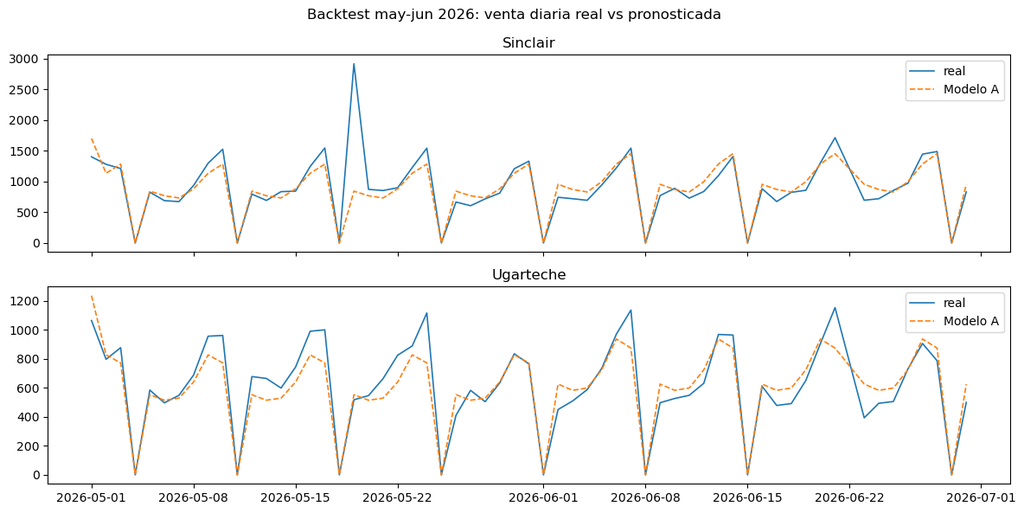

```python
# Visual: predicción vs realidad, total diario por tienda
dia = (ev_a.groupby(['Tienda', 'FECHA'])[['pred', 'real']].sum().reset_index())
fig, axes = plt.subplots(2, 1, figsize=(12, 6), sharex=True)
for ax, tienda in zip(axes, dia['Tienda'].unique()):
    t = dia[dia['Tienda'] == tienda]
    ax.plot(t['FECHA'], t['real'], label='real', lw=1.2)
    ax.plot(t['FECHA'], t['pred'], label='Modelo A', lw=1.2, ls='--')
    ax.set_title(tienda); ax.legend()
plt.suptitle('Backtest may-jun 2026: venta diaria real vs pronosticada')
plt.tight_layout(); plt.show()
```

```python
# Persistimos la predicción del backtest: el notebook 04 la usa para comparar modelos
pred_a.to_parquet('pred_bt_a.parquet')
print('Guardado pred_bt_a.parquet ✔')
```

```
Guardado pred_bt_a.parquet ✔
```

**Conclusión del paso 3:** el Modelo A ya supera con claridad al método anterior en todos los niveles, con solo dos ingredientes explicables a cualquier gerente. Queda como **vara a batir**.

**Próximo paso (notebook 04):** Modelo B — LightGBM con features de calendario y producto — evaluado con el mismo protocolo. La pregunta que responde: ¿el ML paga sobre un baseline bien hecho, y dónde?